# Code_template_normalized

Victoria Rios

16/3/2021

#Análisis de datos de BRCA TN TCGA

Primero definimos la opción para no se lean los strings como factores.

```r
options(stringsAsFactors = F)
```

Primero leemos los datos clínicos.

```r
brca_clin <- read.delim(file = "BRCA.clin.merged.txt", sep = "\t", header = F,
row.names = 1, as.is = T)
```

Obtenemos los datos para los 3 receptores en los renglones 24, 29 y 1160.

```r
print(rownames(brca_clin)[c(24,29,1160)])
```

```
## [1] "patient.breast_carcinoma_estrogen_receptor_status"
## [2] "patient.breast_carcinoma_progesterone_receptor_status"
## [3] "patient.lab_proc_her2_neu_immunohistochemistry_receptor_status"
```

Índices de muestras triple negativo (TN)

```r
index_TN <- which(as.character(brca_clin[24,]) == "negative" &
as.character(brca_clin[29,]) == "negative" &
as.character(brca_clin[1160,]) == "negative")
```

Filtramos para tener datos sólo de los TN y obtenemos las claves de las muestras

```r
brca_clin <- brca_clin[,index_TN]
tn_samples <- toupper(as.character(brca_clin[21,]))
```

Leer datos de RNA-seq

```r
f <- "BRCA.rnaseqv2__illuminahiseq_rnaseqv2__unc_edu__Level_3__RSEM_genes_normalized__data.data.txt"
brca_rnaseq <- read.delim(file = f, sep="\t", as.is=T, row.names = 1)
brca_rnaseq <- data.matrix(brca_rnaseq[-1,])
```

Extraer gene symbols

```r
gene_symbols <- as.character(sapply(rownames(brca_rnaseq), function(x)
unlist(strsplit(x = x, split = "\\|"))[1]))
```

Eliminar renglones con gene symbol igual a “?”

```r
brca_rnaseq <- brca_rnaseq[which(gene_symbols != "?"),]
gene_symbols <- gene_symbols[which(gene_symbols != "?")]
```

Ver el tipo de muestra de acuerdo al TCGA barcode y quitar los normales (tipo “11”) https://docs.gdc. cancer.gov/Encyclopedia/pages/TCGA_Barcode/

```r
sample_type <- substr(x = colnames(brca_rnaseq), start = 14, stop = 15)
brca_rnaseq <- brca_rnaseq[,-which(sample_type == "11")]
sample_type <- sample_type[-which(sample_type == "11")]
```

Hacer match entre las muestras TN y los de RNAseq

```r
tn_match <- match(gsub(pattern = "-", replacement = "\\.", x = tn_samples),
substr(x = colnames(brca_rnaseq), start = 1, stop = 12))
tn_match_na <- which(is.na(tn_match))
brca_clin <- brca_clin[,-tn_match_na]
tn_samples <- tn_samples[-tn_match_na]
tn_match <- tn_match[-tn_match_na]
brca_rnaseq <- brca_rnaseq[,tn_match]

brca_rnaseq_t <- t(brca_rnaseq) # Transpose of Rnaseq
```

# Normalization of the dataset

```r
brca_rnaseq_n <- log2(brca_rnaseq_t + 1)
```

It’s time to build the distance matrix. We use the euclidean distance method.

```r
temp <- brca_rnaseq_n
row.names(temp) <- seq(1, nrow(temp))

d <- dist(temp, method = 'euclidean')
```

## Hierarchial clustering

We proceed with average linkage method.

```r
h <- hclust(d, method = 'average')
```

Looking at the dendogram

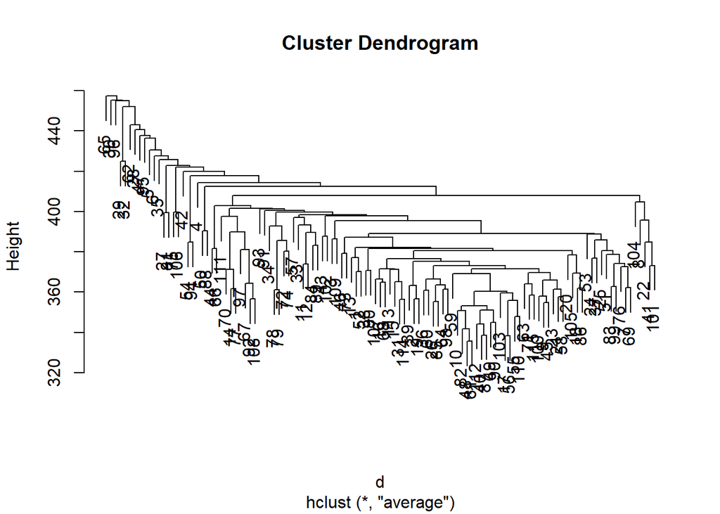

```r
plot(h)
```

Next, we can cut the dendrogram in order to create the desired number of clusters.

```r
cut_avg <- cutree(h, k=10)
```

```r
library(dplyr)
```

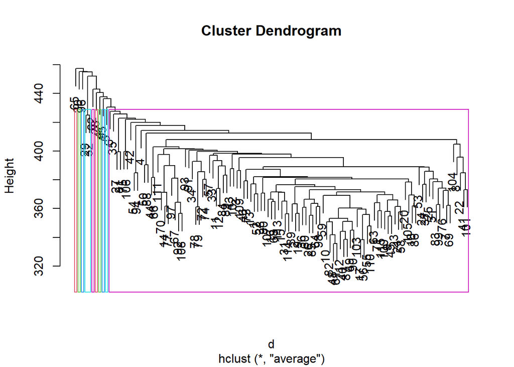

```r
plot(h)
rect.hclust(h , k = 10, border = 2:6)
abline(h = 10, col = 'red')
```

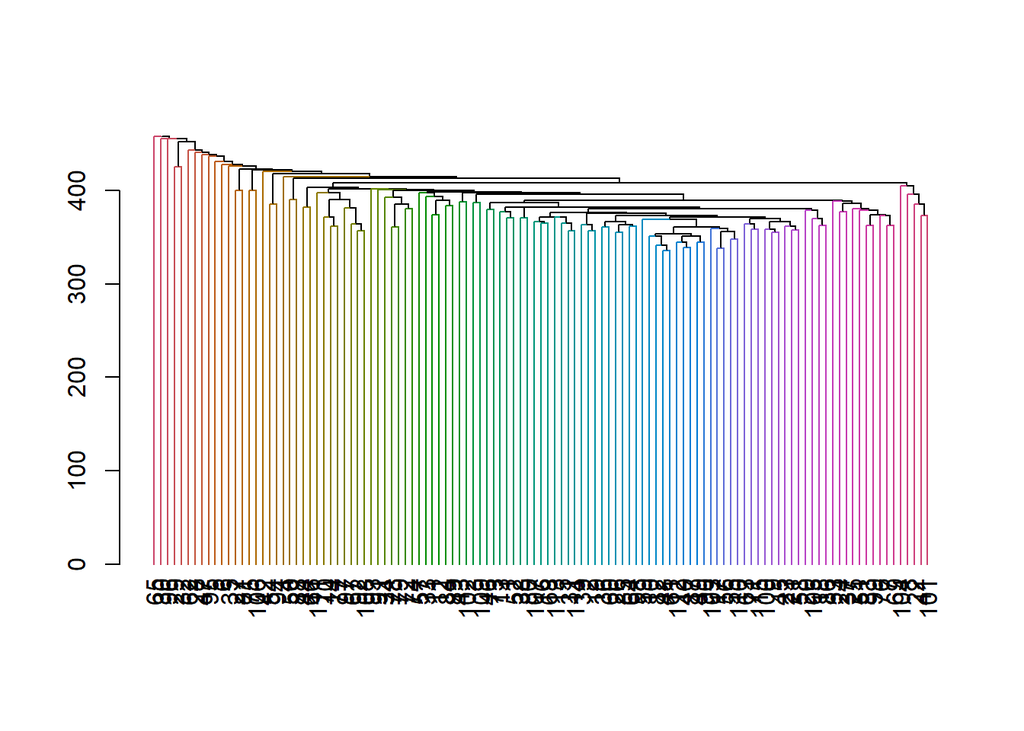

```r
suppressPackageStartupMessages(library(dendextend))
avg_dend_obj <- as.dendrogram(h)
avg_col_dend <- color_branches(h, h = 10)
plot(avg_col_dend)
```

# Clustering the original data set (normalized)

```r
k <- kmeans(brca_rnaseq_n, centers = 3)
```

The cluster assignments are in the cluster component:

```r
groups <- k$cluster
```

Note that because the first center is chosen at random, the final clusters are random. We impose some stability by repeating the entire function several times and averaging the results. The number of random starting values to use can be assigned through the nstart argument.

```r
k <- kmeans(x = brca_rnaseq_n, centers = 3, nstart = 25, iter.max = 800)
```

## Heatmaps

The first step is compute:

```r
brca_rnaseq_df <- as.data.frame(brca_rnaseq_n)

x <- sweep(brca_rnaseq_df, 2, colMeans(brca_rnaseq_df))
```

### Filtering features

```r
library(matrixStats)
```

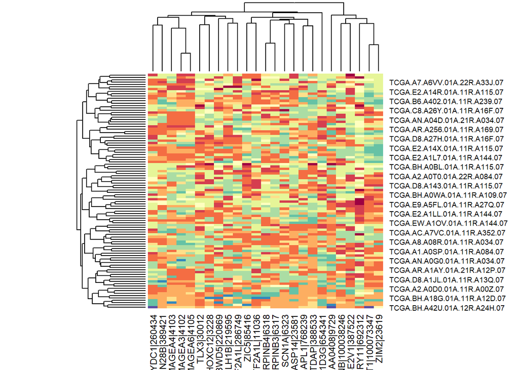

```r
x <- as.matrix(x)
sds <- colSds(x, na.rm = TRUE)
o <- order(sds, decreasing = TRUE)[1:25]
heatmap(x[1:100,o], col = RColorBrewer::brewer.pal(11, "Spectral"))
```

# Clustering PCA results (normalized)

## PCA

```r
# Principal components
x <- prcomp(brca_rnaseq_n, scale = FALSE)
```

```r
library(factoextra)
```

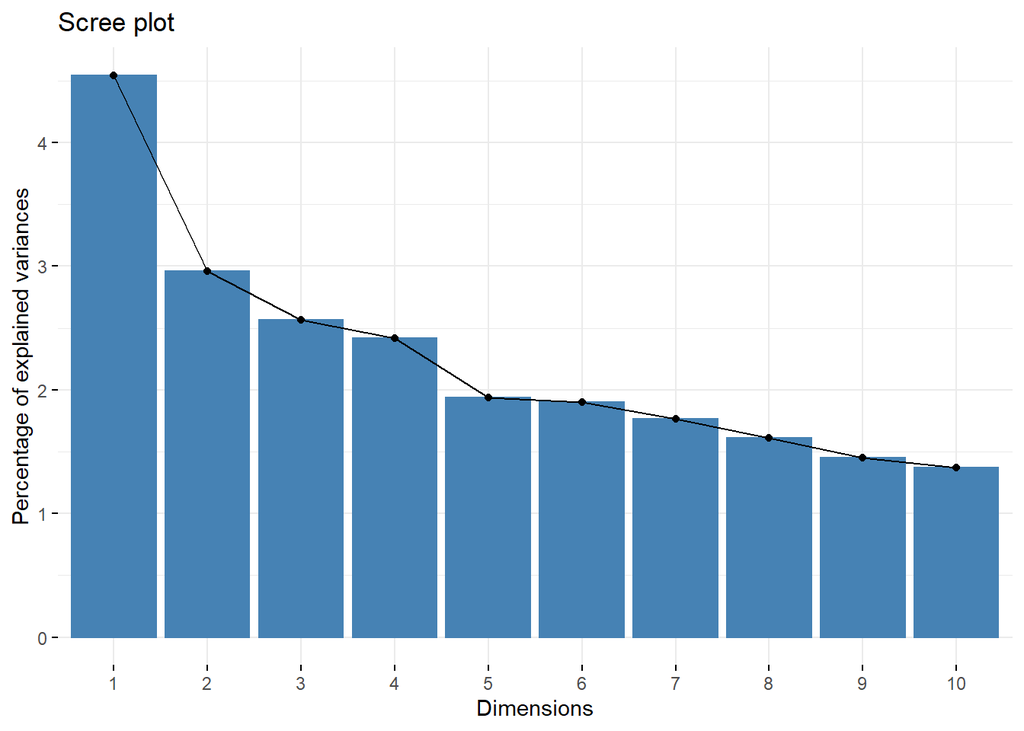

```r
#Visualize eigenvalues (scree plot). Show the percentage of variances explained by each principal component.
fviz_eig(x)
```

## Graph of individuals. Individuals with a similar profile are grouped together.

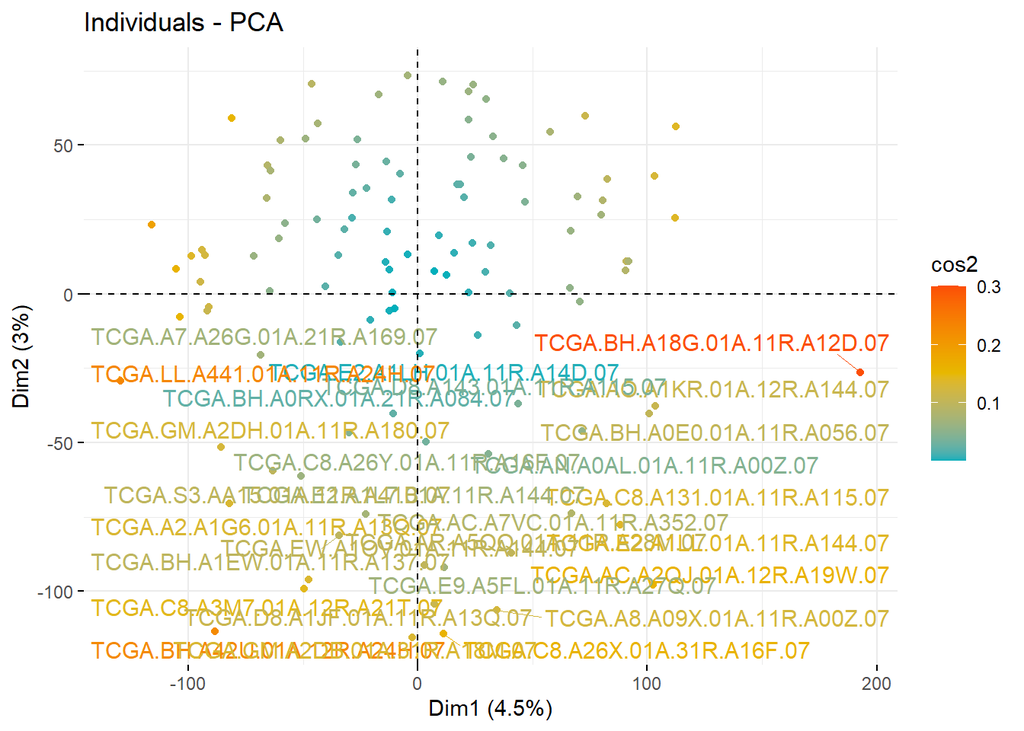

```r
fviz_pca_ind(x,
             col.ind = "cos2", # Color by the quality of representation
             gradient.cols = c("#00AFBB", "#E7B800", "#FC4E07"),
             repel = T,     # Avoid text overlapping,
             max.overlaps = Inf
             )
```

## Graph of variables.

Positive correlated variables point to the same side of the plot. Negative correlated variables point to opposite sides of the graph.

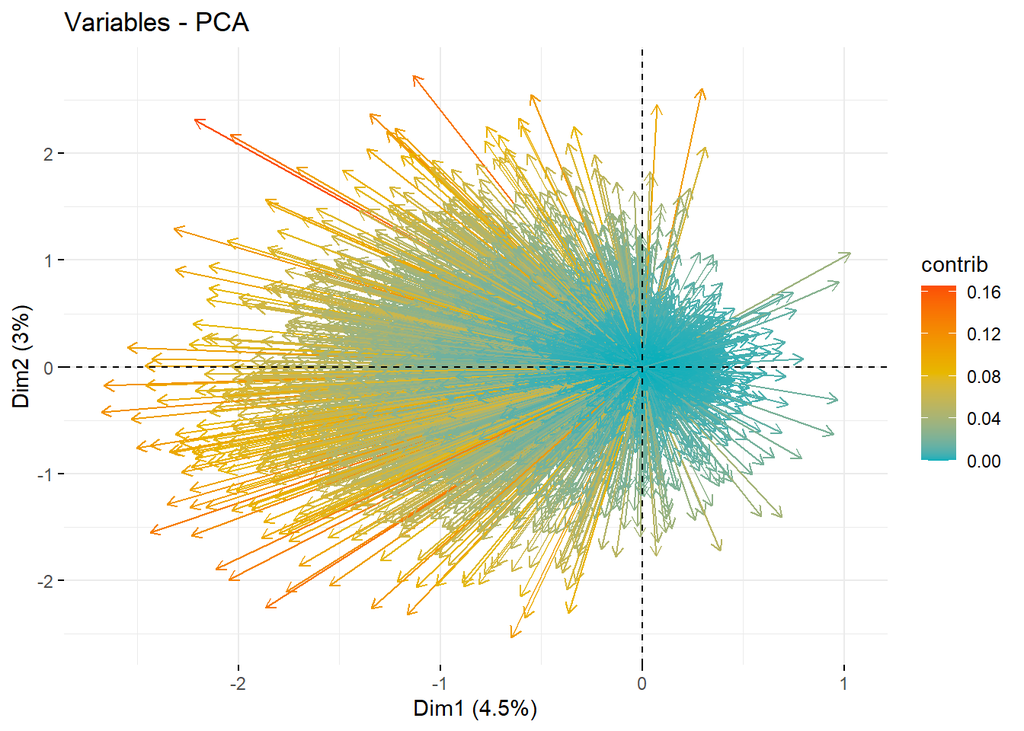

```r
fviz_pca_var(x,
             col.var = "contrib", # Color by contributions to the PC
             gradient.cols = c("#00AFBB", "#E7B800", "#FC4E07"),
             repel = TRUE     # Avoid text overlapping
             )
```

## Biplot of individuals and variables

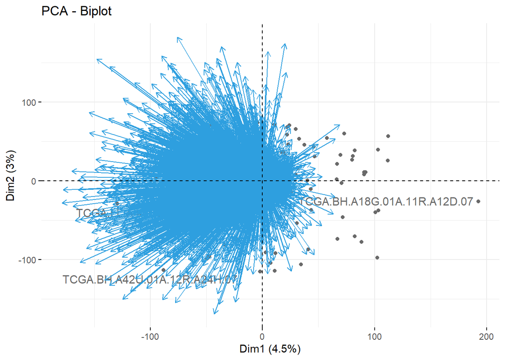

```r
fviz_pca_biplot(x, repel = TRUE,
                col.var = "#2E9FDF", # Variables color
                col.ind = "#696969"  # Individuals color
                )
```

## K-means with PCA results

```r
# Coordinates of individuals
ind.coord <- as.data.frame(get_pca_ind(x)$coord)

head(ind.coord)
```

[output not shown]

[output cut: 148 more lines]

```
## TCGA.A2.A04U.01A.11R.A115.07 -11.561800  4.8768069  5.103851   0.03944796
##                                 Dim.110    Dim.111    Dim.112    Dim.113
## TCGA.A1.A0SP.01A.11R.A084.07  -1.998397   2.862327  -6.936057  15.727734
## TCGA.AR.A1AR.01A.31R.A137.07 -34.880838 -13.563958  -4.942301   2.313104
## TCGA.AR.A2LR.01A.12R.A18M.07 -20.860566  -6.846620 -10.547611 -12.186824
## TCGA.E2.A158.01A.11R.A12D.07  -6.050519   6.907259   1.577559   4.015586
## TCGA.A1.A0SK.01A.12R.A084.07  -1.029316  -6.971576   2.868685  -8.309488
## TCGA.A2.A04U.01A.11R.A115.07  -2.453370   3.885556  -4.780379   4.411809
##                                  Dim.114       Dim.115
## TCGA.A1.A0SP.01A.11R.A084.07  -8.3014872  1.392608e-13
## TCGA.AR.A1AR.01A.31R.A137.07  18.1036912  1.223915e-13
## TCGA.AR.A2LR.01A.12R.A18M.07   7.4571921 -6.368575e-14
## TCGA.E2.A158.01A.11R.A12D.07 -11.7068084  7.283547e-14
## TCGA.A1.A0SK.01A.12R.A084.07  -0.5300006  6.061478e-14
## TCGA.A2.A04U.01A.11R.A115.07   3.4555030  4.064160e-14
```

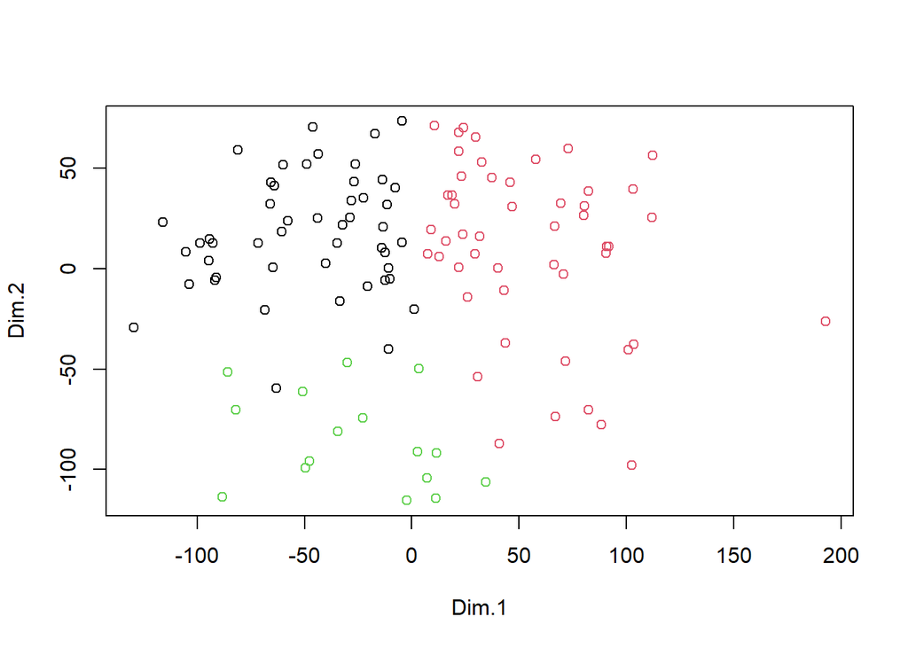

```r
kc <- kmeans(ind.coord, 3)

plot(ind.coord[,1:2],col=factor(kc$cluster))
```

```r
# Add clusters obtained using the K-means algorithm
ind.coord$cluster <- factor(k$cluster)
```

```r
# Percentage of variance explained by dimensions
eigenvalue <- round(get_eigenvalue(x), 1)
variance.percent <- eigenvalue$variance.percent

head(eigenvalue)
```

```
##       eigenvalue variance.percent cumulative.variance.percent
## Dim.1     3760.7              4.5                         4.5
## Dim.2     2447.8              3.0                         7.5
## Dim.3     2124.6              2.6                        10.1
## Dim.4     1999.4              2.4                        12.5
## Dim.5     1603.8              1.9                        14.4
## Dim.6     1571.8              1.9                        16.3
```

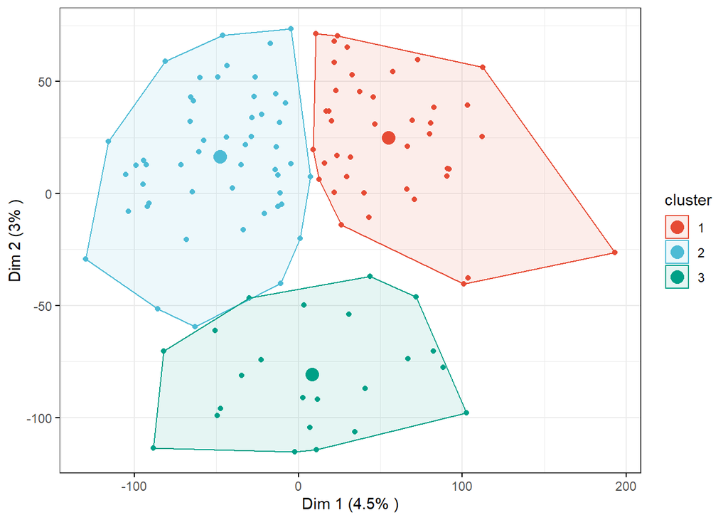

```r
library(ggpubr)
ggscatter(
  ind.coord, x = "Dim.1", y = "Dim.2",
  color = "cluster", palette = "npg", ellipse = TRUE, ellipse.type = "convex", size = 1.5,  legend = "right", ggtheme = theme_bw(),
  xlab = paste0("Dim 1 (", variance.percent[1], "% )" ),
  ylab = paste0("Dim 2 (", variance.percent[2], "% )" )
) +
  stat_mean(aes(color = cluster), size = 4)
```

# K-means with PCA results (not normalized)

## PCA

```r
# Principal components
x <- prcomp(brca_rnaseq_t, scale = FALSE)
```

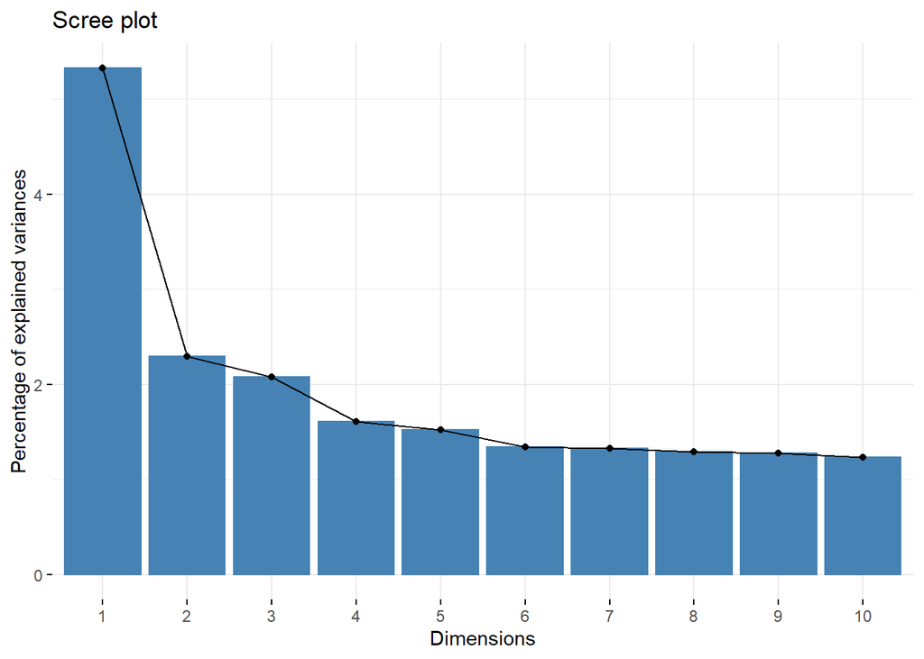

```r
#Visualize eigenvalues (scree plot). Show the percentage of variances explained by each principal component.
fviz_eig(x)
```

## Graph of individuals. Individuals with a similar profile are grouped together.

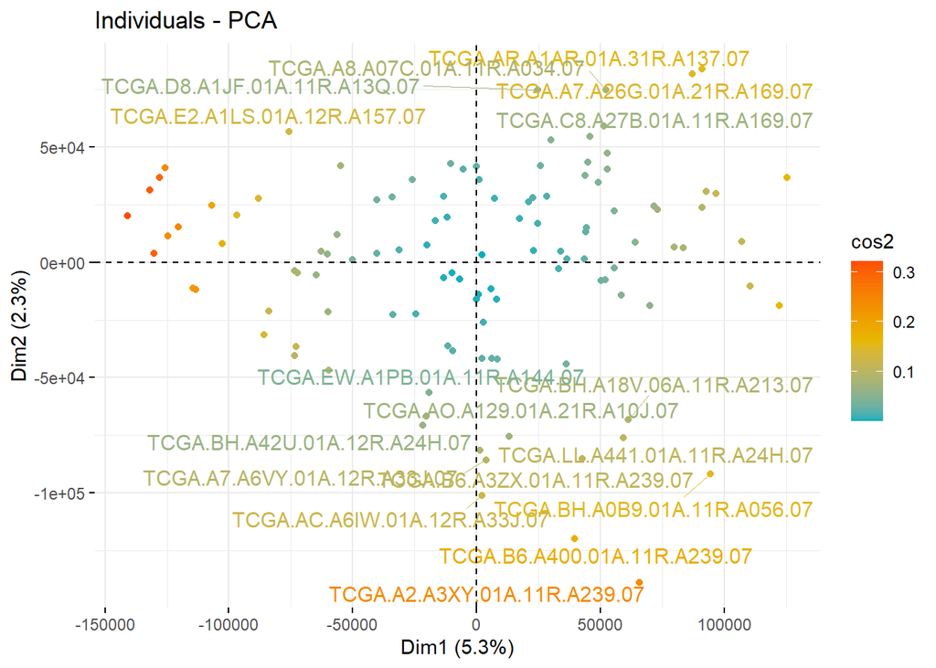

```r
fviz_pca_ind(x,
             col.ind = "cos2", # Color by the quality of representation
             gradient.cols = c("#00AFBB", "#E7B800", "#FC4E07"),
             repel = T,     # Avoid text overlapping,
             max.overlaps = Inf
             )
```

## Graph of variables.

Positive correlated variables point to the same side of the plot. Negative correlated variables point to opposite sides of the graph.

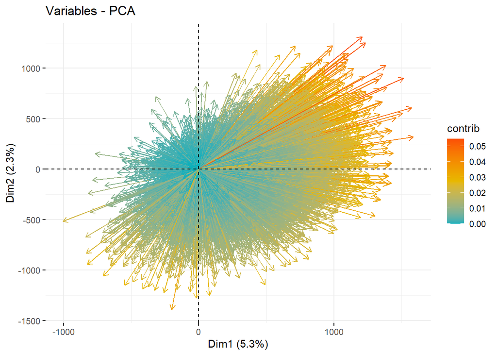

```r
fviz_pca_var(x,
             col.var = "contrib", # Color by contributions to the PC
             gradient.cols = c("#00AFBB", "#E7B800", "#FC4E07"),
             repel = TRUE     # Avoid text overlapping
             )
```

## Biplot of individuals and variables

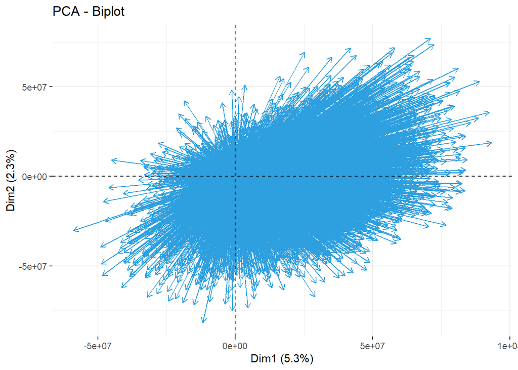

```r
fviz_pca_biplot(x, repel = TRUE,
                col.var = "#2E9FDF", # Variables color
                col.ind = "#696969"  # Individuals color
                )
```

## Getting the coordinates of the PCA results as df

```r
# Coordinates of individuals
ind.coord <- as.data.frame(get_pca_ind(x)$coord)

head(ind.coord)
```

[output not shown]

[output cut: 148 more lines]

```
## TCGA.A2.A04U.01A.11R.A115.07 -8250.8067 23631.373 -7107.954 10550.252 12607.482
##                                 Dim.110    Dim.111    Dim.112    Dim.113
## TCGA.A1.A0SP.01A.11R.A084.07  2259.0378 -4003.1128  2603.7074  -1324.357
## TCGA.AR.A1AR.01A.31R.A137.07 -1147.9286  3684.9508  3295.9094   1289.173
## TCGA.AR.A2LR.01A.12R.A18M.07 10760.2630  2333.9381   179.8578 -11731.219
## TCGA.E2.A158.01A.11R.A12D.07   533.0822  -190.3658  4250.2081  -2425.956
## TCGA.A1.A0SK.01A.12R.A084.07  1077.5490   817.8213 -1235.8662  -3412.250
## TCGA.A2.A04U.01A.11R.A115.07 -6685.6494 16033.6751   588.6379   2019.171
##                                Dim.114       Dim.115
## TCGA.A1.A0SP.01A.11R.A084.07 1512.1789 -1.056761e-10
## TCGA.AR.A1AR.01A.31R.A137.07 2355.6513 -1.584514e-10
## TCGA.AR.A2LR.01A.12R.A18M.07 1224.5489 -1.076907e-10
## TCGA.E2.A158.01A.11R.A12D.07  923.0512 -4.688130e-11
## TCGA.A1.A0SK.01A.12R.A084.07  823.8293  2.865349e-10
## TCGA.A2.A04U.01A.11R.A115.07  520.6298 -6.990211e-11
```

## K means

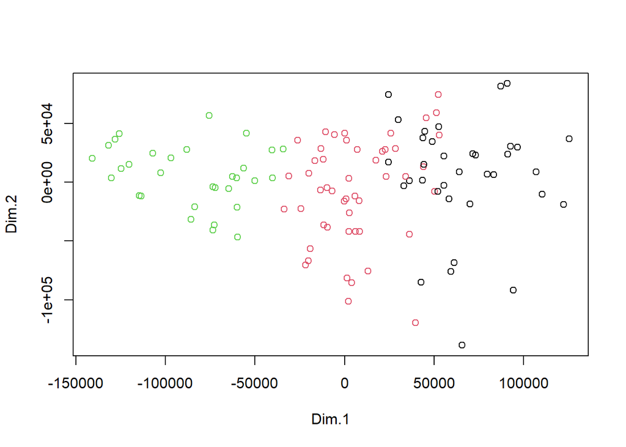

```r
kc <- kmeans(ind.coord, 3)

plot(ind.coord[,1:2],col=factor(kc$cluster))
```

```r
# Add clusters obtained using the K-means algorithm
ind.coord$cluster <- factor(k$cluster)
```

```r
# Percentage of variance explained by dimensions
eigenvalue <- round(get_eigenvalue(x), 1)
variance.percent <- eigenvalue$variance.percent

head(eigenvalue)
```

```
##       eigenvalue variance.percent cumulative.variance.percent
## Dim.1 4081548676              5.3                         5.3
## Dim.2 1754939455              2.3                         7.6
## Dim.3 1589841941              2.1                         9.7
## Dim.4 1231535632              1.6                        11.3
## Dim.5 1163653345              1.5                        12.8
## Dim.6 1025456073              1.3                        14.2
```

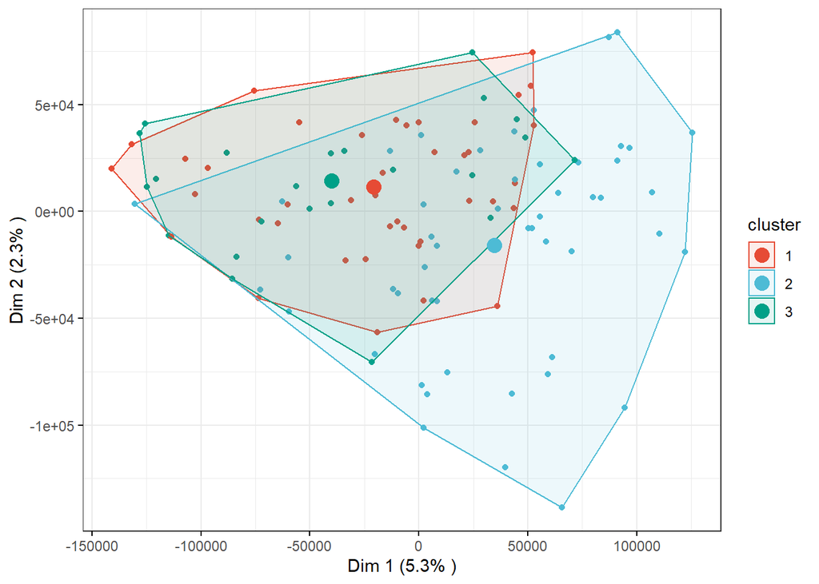

```r
library(ggpubr)

ggscatter(
  ind.coord, x = "Dim.1", y = "Dim.2",
  color = "cluster", palette = "npg", ellipse = TRUE, ellipse.type = "convex", size = 1.5,  legend = "right", ggtheme = theme_bw(),
  xlab = paste0("Dim 1 (", variance.percent[1], "% )" ),
  ylab = paste0("Dim 2 (", variance.percent[2], "% )" )
) +
  stat_mean(aes(color = cluster), size = 4)
```